# Projet HydroScope

Note de cadrage stratégique

Auteur·rice

Affiliation

Hugo Roussaffa

Yapuka SARL

Date de publication

21 mars 2026

**Note de version**

La note de cadrage stratégique (version du 8 mars 2026) prend en compte plusieurs commentaires de Fabien ALBOUY (OEIL), datés du 10 mars 2026, qui visent à rectifier le tir sur la gouvernance, le périmètre contractuel et la communication sur le projet.

Historique des versions du document :

| Version | Date | Auteur | Description des modifications |
| --- | --- | --- | --- |
| Version 0.1 | 2026-03-08 | Hugo Roussaffa | Rédaction initiale de la note de cadrage stratégique |
| Version 0.2 | 2026-03-10 | Hugo Roussaffa | Intégration des commentaires de Fabien ALBOUY (OEIL) sur la gouvernance, le périmètre contractuel et la formulation |

Points en attente (12)

medium (sources) : apporter des chiffres clés sur les menaces liées à la pollution, l’artificialisation des sols, les espèces envahissantes à partir du Dashboard PressionPPE

high (formulation) : “multi-échelles entre le captage et le bassin versant” doit être re-formulé.

high (enjeux) : la modélisation métiers et un modèle décisionnel permettant de répondre à plusieurs enjeux (diagnostic partagé, priorisation proactive, veille environnementale) doit être formulé.

high (cadre) : apporter des précisions sur ce qui est inclus

high (cadre) : apporter des précisions sur ce qui n’est pas inclus

high (sources) : préciser les référentiels de données qui pourront être utilisés

high (sources) : préciser les référentiels de données qui pourront être utilisés

high (Hypothèses) : préciser les hypothèses liées à la mobilisation des financements complémentaires, à l’amendement des conventions en cas de dépassement budgétaire imprévu.

high (Hypothèses) Exprimer la possibilité de mobiliser des ressources internes à l’OEIL, que ce soit au pole environnement qu’au pole SI pour assurer la continuité du projet.

high (planning) : verifier les dates des fins de convention

medium (planning) : planning à reprendre sur Planner et à intégrer dans le document quand j’y aurai accès

high (planning) : Définir et planifier les grands jalons de la Phase B.

**Introduction**

Le projet Hydroscope s’inscrit dans la continuité d’un premier outil développé en 2021 pour la DAVAR (PressionPPE). Suite au retour d’expérience de ce premier projet, l’OEIL a déposé un dossier au fonds PEP en 2023, validé avec un co-financement de l’OFB (65 %) et du fonds PEP (35 %). L’objectif est de faire évoluer cet outil pour répondre aux besoins accrus de connaissance et de gestion de la ressource en eau.

Le projet **Hydroscope** à pour ambition de doter le territoire d’une architecture logiciel et de données robuste, capable de transformer les données brutes en informations stratégiques, en garantissant l’historisation des indicateurs et l’automatisation de la veille sur les pressions environnementales telles que les incendies, l’érosion, la pollution, le développement des espèces envahissantes ou l’artificialisation des sols.

L’OEIL sécurise la continuité intellectuelle du projet initiale (PressionPPE en 2021) et s’efforcera pour que les futurs outils — qu’il s’agisse de tableaux de bord experts, d’interfaces simplifiées pour les partenaires ou de fiches pédagogiques — deviennent des leviers d’aide à la décision pour la protection durable des bassins versants producteurs d’eau potable (BVAEP).

La note de cadrage stratégique sert ainsi à formaliser la vision, les objectifs, la gouvernance et les principes structurants du projet Hydroscope afin de constituer un document de référence garantissant, tout au long de sa mise en œuvre, l’alignement des décisions avec les objectifs stratégiques de l’Observatoire de l’environnement en Nouvelle-Calédonie (OEIL).

# 1 Cadre stratégique et justification du projet

## 1.1 Résumé exécutif

### 1.1.1 Synthèse du projet

Le projet Hydroscope vise à la mise en place d’un Système d’Information Environnemental (SIE) moderne destiné au suivi de la ressource en eau potable sur l’ensemble du territoire de la Nouvelle-Calédonie, succédant au tableau de bord *PressionPPE* (2021). Le projet Hydroscope se fixe pour objectifs de caractériser les BVAEP (incluant les PPE) via leurs facteurs biogéographiques (relief, géologie, végétation, pluviométrie) et les pressions subies (urbanisation, incendies, érosion). Il vise à permettre le partage de ces informations à différentes échelles (Pays, province, commune) via des tableaux de bord numériques adaptés et la production de fiches synthétiques par bassin versant.

### 1.1.2 Finalités stratégiques

Les indicateurs développés permettront de suivre les pressions environnementales (incendies, érosion, artificialisation, pollution) sur les écosystèmes liés à la ressource en eau potable, notamment :

- des bassins versants producteurs d’eau potable (BVAEP),
- des périmètres de protection des eaux (PPE),
- des points de captage.

### 1.1.3 Décision attendue

L’OEIL assure le pilotage du projet en tant que maître d’ouvrage, en recherchant systématiquement le consensus et la co-construction avec ses partenaires (DAVAR, DASS, Provinces, Communes, Syndicats, associations…). Les décisions sur les indicateurs et fonctionnalités seront prises en concertation avec les contributeurs métiers, afin de garantir l’alignement de l’outil avec les besoins réels.

## 1.2 Contexte et enjeux

### 1.2.1 Contexte interne

#### 1.2.1.1 De PressionPPE à Hydroscope

Le projet Hydroscope succède au tableau de bord **PressionPPE** (2021) qui a permis un premier inventaire des données liées à l’eau potable. Toutefois, ce système a atteint ses limites opérationnelles :

- **Dépendance technique et coûts** : Une forte rigidité liée aux solutions propriétaires (ArcGIS) et aux processus manuels SQL/SIG.
- **Absence de profondeur temporelle** : L’impossibilité d’historiser les indicateurs empêche de suivre les tendances et l’évolution des menaces sur le long terme.
- **Déficit d’usage** : Une ergonomie complexe réservée aux techniciens, ne répondant pas aux besoins des décideurs et du grand public.

Une application ArcGIS Pro a été développée en Province Nord pour le suivi de la ressource en eau potable, qui se limite à ce territoire et ne répond donc pas aux besoins d’un Système d’Information Environnemental global pour l’ensemble de la Nouvelle-Calédonie. Cette application à néanmoins l’avantage de permettre des calcule d’indicateurs multicritères pondérés, une fonctionnalité qui devra être prise en compte dans la conception de la future plateforme Hydroscope. D’autres limites techniques du système actuel incluent :

- Absence d’automatisation de la collecte et de l’analyse des données;
- Difficulté d’intégration de nouvelles sources de données ou de nouveaux indicateurs;
- Forte dépendance à l’environnement ArcGIS (ArcGIS Server / image, ArcGIS Pro);
- Pas d’interfaces adaptées aux différents profils d’utilisateurs (gestionnaires, partenaires, grand public);
- Absence d’historisation des indicateurs, limitant la capacité à suivre les tendances et à analyser les évolutions dans le temps;
- Processus de mise à jour manuel et peu flexible, nécessitant des manipulations SQL et SIG, ce qui rend la maintenance et l’évolution du système complexes.

#### 1.2.1.2 Organisation interne et partenaires

Le projet est porté par l’OEIL, avec le souhait de collaborer avec de nombreux partenaires, tels que :

Les institutions suivantes : DAVAR, DASS, DIMENC, Provinces, Communes, Syndicats de gestion de l’eau (AQUA Nord, SIVOM VKP, CDE), bureaux d’études (SEREG, GEOS4D, GeoImpact, Bioéco, CAPSE) et associations (WWF, comité de population locale).

Cette liste de partenaires sera priorisée par l’équipe projet puis validée en COPRO.

Le chef de projet MOA identifié à l’OEIL est Marjolaine David, avec un appui fort de l’AMOA externe (Yapuka - Hugo Roussaffa) pour la tenue des ateliers, la formalisation du cadrage stratégique, les cadrages fonctionnels et la rédaction du cahier des charges fonctionnel.

Afin d’appuyer les sollicitations de l’équipe projet auprès des partenaires lors des ateliers, l’OEIL sollicitera officiellement une lettre de mission auprès du Gouvernement. Cette démarche vise à légitimer l’implication des services techniques territoriaux.

##### 1.2.1.2.1 Priorisation hiérarchique des besoins

Les besoins des gestionnaires (DAVAR, DASS, Provinces etc.) sont recueillis à titre consultatif. Ils ne sont intégrés que dans la mesure où ils s’alignent à la vision de l’OEIL, ses missions de service public et le temps long.

##### 1.2.1.2.2 Gouvernance et arbitrage final

La structure de pilotage donne un pouvoir décisionnel à l’OEIL :

- **Arbitrage** : l’OEIL s’attache à développé une coordination entre les acteurs. Toutefois, l’analyse critique des attentes ou besoin et l’arbitrage final des points clés reviennent à l’OEIL. Les choix seront discutés collegialement en toute transparance en fonction de sa vision stratégique et ses missions.
- **Coordination** : Le consultant AMOA coordonne la planification et les arbitrages selon la vision de l’OEIL et du chef de projet, en veillant à ce que les besoins des partenaires soient exprimés dans la mesure où ils s’alignent avec les objectifs de l’OEIL.
- **Journal des décisions** : Ce document, tenu par l’AMOA, sert de synthèse pour présenter l’alignement continu sur les objectifs de l’OEIL et limite les aller-retour sur des points arbitrés sauf pour des cas réévalué en COPIL par exemple.

### 1.2.2 Contexte externe : un patrimoine vital sous pression

#### 1.2.2.1 Un cadre réglementaire et institutionnel

L’adoption de la loi du pays n° 2025-9 du 15 juillet 2025 relative au domaine public de l’eau (DPE) et à la protection de la ressource marque une étape majeure dans la modernisation du cadre juridique calédonien.

L’objectif des PPE est de préserver la qualité de la ressource en réglementant ou en interdisant les activités polluantes autour des points de prélèvement, évitant ainsi des frais de traitement onéreux pour les communes et les usagers.

Le rôle de la Nouvelle-Calédonie ne se limite plus seulement aux études techniques, il s’étend désormais à la décision finale de protection :

1. Adoption de l’arrêté : C’est désormais le gouvernement de la Nouvelle-Calédonie qui instaure par arrêté les périmètres de protection (immédiate, rapprochée et éventuellement éloignée).
- Instruction centralisée : Le service de l’eau de la DAVAR est confirmé comme l’instructeur unique pour les demandes d’autorisation de prélèvement et les dossiers de PPE.
- Gestion des urgences : Le gouvernement peut désormais autoriser des prélèvements provisoires sans PPE en cas de circonstances climatiques exceptionnelles ou de pollution accidentelle, à condition qu’il n’y ait pas de danger pour la santé.
2. L’État : Un rôle recentré sur le contrôle de légalité Alors qu’auparavant l’État signait l’arrêté de Déclaration d’Utilité Publique (DUP), la nouvelle loi du pays transfère le pouvoir de décision au gouvernement local :
- Procédure locale : Les modalités de l’enquête publique ne dépendent plus des procédures de l’État mais sont désormais fixées par une délibération du Congrès (n° 522 du 20 novembre 2025).
- Information : L’État (via le Haut-commissaire) reste informé par la transmission des arrêtés et peut être sollicité pour la liste d’aptitude des commissaires enquêteurs, mais le pilotage de la procédure est calédonien.
3. Les Provinces : De la gestion à la consultation Depuis la rétrocession de la compétence “eau” en 2022, leur rôle a évolué vers le conseil et la concertation :
- Avis obligatoire : Les provinces sont désormais systématiquement saisies pour avis lors de l’instruction des dossiers de PPE ou d’autorisations de prélèvements importantes (classes 2, 3 et 4).
- Délégation possible : La loi prévoit que le gouvernement peut déléguer la gestion du domaine public de l’eau (incluant l’entretien ou la délivrance des autorisations) aux provinces via une convention.
- Initiative locale : Elles peuvent demander au gouvernement la création de Conseils Locaux de l’Eau (CLE) pour une gestion concertée par bassin versant.
4. Les Communes : Acteurs de terrain et de consultation Leurs responsabilités en matière de distribution d’eau potable demeurent, mais leur implication dans la procédure de PPE est précisée :
- Consultation systématique : Comme les provinces, les communes doivent donner leur avis sur les projets d’installations ou de PPE situés sur leur territoire.
- Support de l’enquête publique : Les mairies sont les lieux privilégiés pour l’affichage des avis de consultation et la mise à disposition des dossiers papier.
- Initiative des CLE : Elles peuvent également être à l’origine de la création d’un Conseil Local de l’Eau pour mieux gérer les conflits d’usage locaux.
5. Nouveaux échelons et délais imposés La loi introduit de nouveaux éléments qui n’existaient pas dans le cadre précédent :
- Les Autorités Coutumières : Elles deviennent un échelon indispensable. L’instauration d’un PPE sur terres coutumières est désormais strictement conditionnée à l’accord des autorités coutumières, matérialisé par un acte coutumier.
- Obligation de régularisation : Pour les captages existants qui n’auraient pas encore de PPE, les gestionnaires disposent d’un délai d’un an (à compter du 15 juillet 2025) pour fournir le dossier nécessaire à leur détermination.
- Participation du public simplifiée : Pour les PPE concernant moins de 12 propriétaires (et sans impact économique majeur), une simple consultation publique de 15 jours remplace la lourde procédure d’enquête publique.

#### 1.2.2.2 État de la menace

Le projet répond à une urgence environnementale caractérisée par :

- **Incendies** : En 2019, **17 % des feux de brousse** ont touché des PPE (7 000 hectares);
- **Érosion** : La couverture végétale est dégradée dans **90 % des PPE** de Nouvelle-Calédonie;
- **Changement climatique** : Une baisse de **20 % des précipitations** est projetée d’ici 2100;
- **Humain** : La protection de la ressource en eau représente un enjeux vitale pour **271 407 habitants** et **90 800 ménages** .

@todo [priority=medium,section=sources] : apporter des chiffres clés sur les menaces liées à la pollution, l’artificialisation des sols, les espèces envahissantes à partir du Dashboard PressionPPE

#### 1.2.2.3 Défis stratégiques et réponses du projet

#### 1.2.2.4 Le Fonds PEP : un levier stratégique et financier

Le fonds PEP constitue un levier financier et stratégique majeur en assurant 35 % du financement du projet, en complément des 65 % apportés par l’Office Français de la Biodiversité. L’un des enjeux critiques réside dans la conformité contractuelle et le respect des jalons, car la production du premier rapport détaillant les critères et fiches indicateurs conditionne le versement de 30 % du budget global. L’objectif opérationnel final est de transformer l’outil existant **PressionPPE** vers un système capable de quantifier plus précisément l’intégrité de la ressource en eau potable pour l’ensemble du territoire. Cette sécurisation financière permet de garantir la viabilité de l’ingénierie déployée par l’OEIL sur du plus long terme.

**Défi financier :**

- **Enjeu** : Garantir la viabilité du projet via le co-financement **OFB (65 %)** et **PEP (35 %)**;
- **Réponse** : Livraison prioritaire du **rapport de critères et fiches indicateurs**, conditionnant le premier versement de **30 % du budget**.

#### 1.2.2.5 Connaissance et diagnostic territorial

Sur le plan de la connaissance territoriale, l’enjeu est de passer d’un simple inventaire passif à un véritable outil de pilotage proactif permettant d’identifier les bassins les plus vulnérables pour mieux orienter les budgets de gestion. Pour y parvenir, le projet vise la caractérisation biogéographique fine des Bassins Versants producteurs d’Eau Potable (BVAEP), des périmètres de protection (PPE) et des points de captage. Cet objectif s’appuie sur la mise en œuvre d’une **analyse multicritère** utilisant des seuils de vigilance définis collectivement et l’intégration des données de l’ISEE pour évaluer la population desservie. Ce diagnostic partagé doit permettre à tous les échelons institutionnels de disposer d’un **constat commun** sur l’état de la ressource.

**Défi décisionnel :**

- **Enjeu** : Passer d’un constat passif à une **priorisation proactive** des choix d’investissement, aux actions de terrain;
- **Réponse** : Mise en place d’une **analyse multicritère** (seuils de vigilance et pondérations) intégrant les données biogéographiques et la population desservie (ISEE).

#### 1.2.2.6 Automatisation et système d’alerte

L’automatisation répond au défi de la réactivité des gestionnaires, en cherchant à réduire le délai entre un événement environnemental et son signalement pour limiter l’impact sur la ressource. L’enjeu est également de garantir la **fiabilité de l’information** en s’affranchissant de manipulations manuelles répétitives et chronophages. L’objectif technique est d’intégrer des algorithmes de **détection automatique des changements**(incendies, défrichements, nouvelles installations classées) déclenchés dès l’intégration de nouvelles données de référence. Le système doit assurer une **veille environnementale** constante en automatisant la récupération de flux de données exogènes réguliers.

**Défi de réactivité :**

- **Enjeu** : Réduire le délai de signalement des pressions (incendies, défrichages, pollution) pour protéger les captages et informer les populations;
- **Réponse** : Déploiement d’une **chaîne ETL automatisée** incluant des algorithmes de **détection automatique de changements** (méthodes Hash MD5 ou Geodiff).

#### 1.2.2.7 Pilotage technique et aide à la décision, un diagnostic partagé

Le pilotage technique vise à instaurer un **diagnostic partagé** entre le Gouvernement, les Provinces et les Communes, tout en rendant la donnée exploitable par des utilisateurs non-spécialistes en SIG. Les livrables incluent le développement de **trois interfaces profilées** (Expert, Partenaire, Grand Public) dont l’ergonomie et les fonctionnalités sont adaptées aux missions spécifiques de chaque public. L’objectif fonctionnel est de permettre une navigation multi-échelles entre le captage et le bassin versant, complétée par la **production de rapports** de synthèse automatisés au format PDF.

@todo [priority=high,section=formulation] : “multi-échelles entre le captage et le bassin versant” doit être re-formulé.

**Défi d’accessibilité :**

- **Enjeu** : Permettre à tous les acteurs (mairies, provinces, gouvernement, État, aires coutumières, associations) de partager un constat commun;
- **Réponse** : Développement de **trois interfaces profilées** (Expert, Partenaire, Grand public) et automatisation des **rapports de synthèse PDF**.

#### 1.2.2.8 Continuité et pérennité opérationnelle

La pérennité opérationnelle du projet repose sur **l’indépendance technologique** vis-à-vis des logiciels propriétaires et le maintien de la **continuité intellectuelle** avec les travaux réalisés depuis 2021. L’enjeu est de s’affranchir de la dette technique et des coûts de licence pour garantir la durabilité du système à moindre coût (financiers et effort de maintenance). Pour cela, les objectifs de réalisation imposent l’utilisation d’une **chaîne de traitement (ETL/ELT) automatisée** et une orchestration moderne utilisant des technologies Open Source comme PostgreSQL/PostGIS, Python et DBT. Enfin, la mise en place d’une **historisation systématique** des indicateurs et des données sources, catalogués et documentés, est un prérequis majeur pour permettre des analyses temporelles et suivre l’évolution de la ressource sur le temps long.

**Défi de pérennité :**

- **Enjeu** : Piloter autant que possible les maintenances et éviter des dettes techniques et assurer le suivi et la veille des données;
- **Réponse** : Migration vers un socle **Open Source** (PostgreSQL/PostGIS, Python, DBT) garantissant l’**historisation systématique** des données.

@todo [priority=high,section=enjeux] : la modélisation métiers et un modèle décisionnel permettant de répondre à plusieurs enjeux (diagnostic partagé, priorisation proactive, veille environnementale) doit être formulé.

# 2 Définition du cadre opérationnel du projet

## 2.1 Périmètre du projet

Le projet s’articule autour de quatre domaines prioritaires :

- Caractériser les territoires (facteurs biogéographiques et pressions).
- Assurer une veille environnementale et alerter (détection automatique des changements).
- Partager des diagnostics entre acteurs (interfaces adaptées par profil).
- Synthétiser l’information (rapports automatisés et fiches)

### 2.1.1 Ce qui est inclus

Le projet Hydroscope intègre une navigation permettant de circuler de manière fluide entre les territoires, les bassins versants (BVAEP), les périmètres de protection (PPE) et les points de captage. Les fonctionnalités incluent la production de **tableaux de bord experts** pour le pilotage technique et la génération automatisée de **rapports de synthèse au format PDF**. Les données traitées couvrent les indicateurs de pression (incendies, érosion, urbanisation), la population desservie via l’intégration des statistiques de l’ISEE, ainsi que des informations biophysiques clés.

Le Bassin AEP est l’unité principale de gestion (plutôt que le PPE seul), car tous les captages n’ont pas de périmètre protégé. La pondération multi-critère (méthode par “jauge”) est jugé essentiel par la DAVAR et l’OEIL.

@todo [priority=high,section=cadre] : apporter des précisions sur ce qui est inclus

### 2.1.2 Ce qui est considéré comme hors périmètre

Le système ne prévoit pas l’accès aux **données brutes** comme les mesures physico-chimiques par exemples, ou la pluviométrie (valeurs précises), mais se limite à conserver l’historique de présence, les dates des prélèvements effectués ou des indicateurs moyens. Par ailleurs, les actions de **vulgarisation pédagogique approfondie** ne sont pas traitées ici, car elles sont déportées vers le projet partenaire nommé **SOURCE**.

@todo [priority=high,section=cadre] : apporter des précisions sur ce qui n’est pas inclus

## 2.2 Hypothèses et contraintes

### 2.2.1 Disponibilité et la fiabilité des données

La réussite du projet repose en grande partie sur l’accès aux données fournies par les partenaires institutionnels (Gouvernement, Provinces, Communes, DASS, ISEE…).

Le projet doit assurer l’interopérabilité entre les référentiels de la DAVAR, de la DITTT (BD-Hydrographie) et du BRGM (BD-Lisa) etc.

Voici une liste des référentiels hydrologiques produits par des acteurs en Nouvelle-Calédonie :

- BD-Lisa (BRGM) : Référentiel hydrographique à l’échelle du territoire, utilisé pour la modélisation des masses d’eau Base de Données des Limites des Systèmes Aquifères.
- BD-Hydrographie (DITTT) : Réseau hydrographique de la Grande Terre. Donnée composée du réseau hydrographique principal, secondaire et surfacique sur la Grande Terre de la Nouvelle-Calédonie. Des informations concernant le nom des cours d’eau principaux et leur longueur sont également disponibles. Cette donnée est issue de la BDCARTO (1/50.000) de la Direction des Infrastructures, de la Topographie et des Transports Terrestres (DITTT).
- Cartographie des Périmètres de Protection des Eaux;
- Positionnement des captages destinés à l’Alimentation en Eau Potable;
- Positionnement des captages privés autorisés;
- Emplacements et métadonnées des stations de suivi du débit des cours d’eau et pluviométrique de la DAVAR;
- Cartographie résultant d’études sur les débits des cours d’eau ou sur la pluviométrie;
- Cartographie des Hydro-Eco Régions;
- Carnet ou base de données de suivi des captages par la DASS inscrivant les opération de sécurité sanitaire des réseaux d’eau potable. Ces carnets/Base de données font partit du Plan de Sécurité Sanitaire des Eaux (PSSE).

Des référentiels non hydrologiques produit en Nouvelle-Calédonie seront exploités :

- MNT;
- Météo;
- Incendies;
- Sécheresse végétale;
- Plans Locaux d’Urbanisme (PUD);

@todo [priority=high,section=sources] : préciser les référentiels de données qui pourront être utilisés

D’autres référentiels hydrologiques et non hydrologiques produit en dehors de la Nouvelle-Calédonie pourront être exploités :

- Dynamic world;
- TMF;
- SWOT
- …

@todo [priority=high,section=sources] : préciser les référentiels de données qui pourront être utilisés

Il est également hypothéqué que les partenanires et acteurs institutionnels s’engagent activement dans la validation des indicateurs et la définition des seuils de vigilance, garantissant ainsi l’appropriation du diagnostic territorial partagé.

### 2.2.2 Stabilité des financements

Enfin, le projet suppose une **stabilité des financements** et un respect rigoureux des jalons contractuels avec le fonds PEP pour assurer la continuité de l’ingénierie déployée par l’OEIL.

@todo [priority=high,section=Hypothèses] : préciser les hypothèses liées à la mobilisation des financements complémentaires, à l’amendement des conventions en cas de dépassement budgétaire imprévu.

### 2.2.3 Ressources humaines

@todo [priority=high,section=Hypothèses] Exprimer la possibilité de mobiliser des ressources internes à l’OEIL, que ce soit au pole environnement qu’au pole SI pour assurer la continuité du projet.

## 2.3 Estimation budgétaire macro

Le financement est structuré par le co-financement entre l’**OFB (65 %)** et le **fonds PEP (35 %)**. Sur la base des premières études, la charge de développement des interfaces de consultation est pour le moment estimée entre **7 et 9 M XPF**, montant pouvant être optimisé selon les possibilités de mutualisation technique et l’analyse plus fine des besoins au cours de la phase A. Les coûts de maintenance et d’hébergement sont estimés à environ **1 M XPF par an** après la mise en production, avec une attention particulière portée à la maîtrise des coûts liés à l’infrastructure cloud et à l’optimisation des traitements automatisés.

## 2.4 Planning macro

Le calendrier est soumis à deux échéances contractuelles majeures :

- 29 décembre 2026 : Date limite cible pour la livraison des outils.
- 31 mars 2028 : Clôture définitive de la convention avec l’OFB

@todo [priority=high,section=planning] : verifier les dates des fins de convention

Le projet est découpé en deux étapes majeures : une première phase de **cadrage fonctionnel** (Phase A) d’une durée de 3 mois, suivie d’une phase de **réalisation technique** (Phase B) . Les points de validation clés incluent la livraison des fiches indicateurs et du **Cahier des Charges Fonctionnel (CCF)**.

### 2.4.1 Mois 1 : Gouvernance et cadrage stratégique (mi-Mars à mi-Avril 2026)

Ce mois est dédié à la mise en place du cadre de travail et à la définition des principes fondamentaux du projet.

13 Mars 2026 : Réunion de lancement (Kick-off) avec l’OEIL et les financeurs (OFB et DAVAR/PEP).

Semaines 1 à 3 : Entretiens stratégiques et fonctionnel (2 à 3 sessions) avec l’équipe de l’OEIL pour stabiliser la vision.

Semaine 4 : Première réunion du COPRO (suivi opérationnel et planning).

Jalons de livrables :

- Note de cadrage stratégique;
- Notes de cadrage fonctionnel pour les trois domaines : gestionnaires, grand public et besoins internes OEIL.

### 2.4.2 Mois 2 : Cadrage métier et ateliers (mi-Avril à mi-Mai 2026)

Période pour transformer les besoins en spécifications fonctionnelles précises.

Fin-Avril : Deuxième réunion du COPRO.

Mi-Mai : Réunion du COTECH (validation technique des options d’historisation et d’indexation H3).

Jalons de livrables (mi-projet) :

- Revue critique des fiches indicateurs et du modèle PressionPPE (usages et limites);
- Fiches indicateurs Hydroscope : Ce livrable est crucial car il constitue le jalon de paiement PEP (30 % du budget).

### 2.4.3 Mois 3 : Rédaction du cahier des charges fonctionnel et validation (mi-Mai à mi-Juin 2026)

Finalisation de la documentation pour préparer la phase de réalisation technique (Phase B).

Semaines 1 et 2 : Rédaction détaillée des spécifications fonctionnelles, schémas, processus et maquettes fonctionnelles (wireframes).

Jalons de livrables (fin de projet) :

- Cahier des charges fonctionnel Hydroscope (50-60 pages);
- Journal des décisions et arbitrages finalisé;
- Rapport de consolidation finale de la mission AMOA;

Mi-Juin : COPIL de clôture de la Phase A : Présentation finale des livrables et arbitrage pour lancer la réalisation technique (Phase B ).

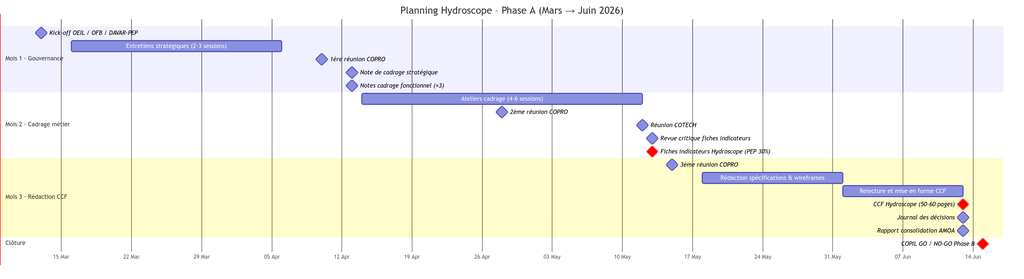

@todo [priority=medium,section=planning] : planning à reprendre sur Planner et à intégrer dans le document quand j’y aurai accès

@todo [priority=high,section=planning] : Définir et planifier les grands jalons de la Phase B.

# 3 Sécurisation, gouvernance et pilotage

## 3.1 Analyse des risques majeurs

### 3.1.1 Risques organisationnels

Risque de frustration des partenaires : L’impossibilité d’intégrer tous les besoins exprimés lors des ateliers peut générer une déception. Une communication claire sur le périmètre stratégique sera faite en amont de chaque atelier.

### 3.1.2 Risques techniques

L’enjeu technique majeur concerne l’hétérogénéité des référentiels sources et la **complexité de l’architecture** (historisation, indexation H3 et calcul d’indicateurs multicritères pondérés).

La stabilisation du **modèle de données métier** et le choix définitif de l’unité principale de gestion, le consensus actuel penchant pour le **Bassin AEP** plutôt que le seul PPE. ces données doivent être solides car le modèle de données métier est un socle structurant pour la réalisation technique et les choix d’architecture.

### 3.1.3 Risques financiers

Il existe un risque lié à la difficulté de mobiliser des financements complémentaires ou d’amender les conventions actuelles en cas de dépassement budgétaire imprévu.

## 3.2 Gouvernance du projet

L’**OEIL** assure la maitrise d’ouvrage du projet. La mission d’**AMOA** est confiée au consultant indépendant Hugo Roussaffa de la société **Yapuka**, garant de la cohérence fonctionnelle et de l’alignement sur les objectifs stratégiques. Le pilotage opérationnel est structuré autour de deux instances : le comité de pilotage **COPIL** et le comité de projet **COPRO** . Une équipe projet dédiée, pilotée par Marjolaine David (CP OEIL) avec l’appui de l’AMOA, est chargée de la coordination quotidienne, la réalisation d’action de gestion de projet, la mise en oeuvre de la récolte des besoins et de la production des livrables.

- COPIL (Stratégique) : Composé de l’OEIL, de l’OFB et du Chef de service de l’eau de la DAVAR (ou son représentant). Son rôle est l’arbitrage des besoins synthétisés.
- COPRO (Opérationnel) : Intègre les chefs de projet techniques de l’OEIL et le comité OS1 (DAVAR, DASS, DIMENC, 3 provinces, communes). Il garantit l’alignement des besoins recensés avec le périmètre du projet.
- Équipe projet : Pilotée par Marjolaine David (CP OEIL) avec l’appui de l’AMOA (Yapuka).

## 3.3 Indicateurs de pilotage

Le suivi de la valeur métier du projet s’appuiera sur le **nombre d’indicateurs priorisés et validés scientifiquement** par les experts. La traçabilité des arbitrages sera assurée par un **journal des décisions** tenu à jour par l’AMOA tout au long de la phase de cadrage.

## 3.4 Prochaines étapes

Le lancement opérationnel passera par la validation de cette note de cadrage et une **revue critique des indicateurs actuels** de PressionPPE. Plannification des **ateliers thématiques** avec les gestionnaires pour la période (Avril-Mai). Ces ateliers permettront vue de finaliser les fiches indicateurs (jalon PEP) et de définir les besoins métiers détaillés, qui serviront de base à la rédaction du **Cahier des Charges Fonctionnel** final.

## Droits d'auteur

Copyright Yapuka SARL - 2026. Tous droits réservés. Version document 0.2